# Leave-One-Out Brier Score for Bayesian Survival Models

Using Pareto smoothed importance sampling

Eren M. Elçi

2018-12-17

In this short case study we show how to implement an estimator for the leave-one-out (LOO) version of the Expected Brier Score for Bayesian Survival Models, with right-censored event times. We utilize the so-called “inverse of probability of censoring weighted estimator” and use an efficient computation method to calculate LOO for all individuals based on pareto-smoothed importance sampling.

References:

> Vehtari, Aki, Andrew Gelman, and Jonah Gabry. “Practical Bayesian model evaluation using leave-one-out cross-validation and WAIC.” Statistics and Computing 27.5 (2017): 1413-1432. APA

> Gerds, Thomas A., and Martin Schumacher. “Consistent estimation of the expected Brier score in general survival models with right‐censored event times.” Biometrical Journal 48.6 (2006): 1029-1040.

# The dataset

| time | event | metastized |
| --- | --- | --- |
| 23 | TRUE | 0 |
| 47 | TRUE | 0 |
| 69 | TRUE | 0 |
| 70 | FALSE | 0 |
| 100 | FALSE | 0 |
| 101 | FALSE | 0 |
| 148 | TRUE | 0 |
| 181 | TRUE | 0 |
| 198 | FALSE | 0 |
| 208 | FALSE | 0 |

[output cut: 34 more lines]

For more details on the dataset and how to model aspects of it using Bayesian survival models (in Stan), see my previous case study [here](https://ermeel86.github.io/case_studies/surv_stan_example.html).

# The models

```r
N <- nrow(df)
X <- as.matrix(as.integer(pull(df, metastized))-1)
is_censored <- pull(df,event)==0
times <- pull(df,time)
msk_censored <- is_censored == 1
N_censored <- sum(msk_censored)

time_range <- range(times)
time_min <- time_range[1]
time_max <- time_range[2]
```

We implement two proportional hazard models with different baseline hazards and show below prior predictive draws of the corresponding baseline hazard.

## Constant baseline hazard (aka constant)

As the name suggests, this model uses a constant baseline hazard (and therefore has an exponential law for the event time).

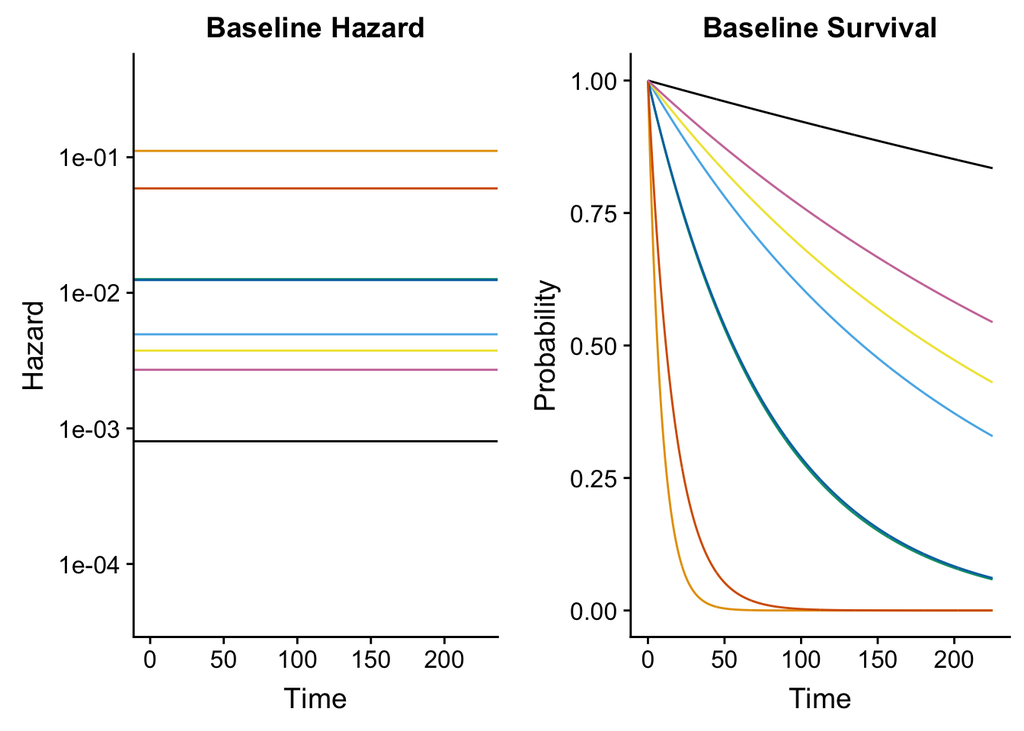

```r
nprior_samples <- 8
icpt_samples <- exp(rnorm(nprior_samples, -5, 2))
# TODO: Replace with direct calls to surv_const_t
df_plot <- map_dfr(1:nprior_samples, ~tibble(time=seq(0, time_max, length.out = 1000), surv=exp(-time*icpt_samples[.]), sample=.))
p1<- ggplot(data=tibble(bhazards=icpt_samples, sample=as.factor(1:nprior_samples)))+
  scale_y_log10(name="Hazard", limits=exp(c(-10, -1))) +
  scale_x_continuous(name="Time", limits=c(0,time_max))+
  geom_hline(aes(yintercept=bhazards, color=sample))+
  guides( color=FALSE)+
  scale_fill_manual(values=cbbPalette)+
  scale_colour_manual(values=cbbPalette)+
  ggtitle("Baseline Hazard")
p2 <- ggplot(data=df_plot)+
  geom_line(aes(x=time, y=surv, color=as.factor(sample)))+
  guides( color=FALSE)+
  scale_fill_manual(values=cbbPalette)+
  scale_colour_manual(values=cbbPalette)+
  xlab("Time")+
  ylab("Probability")+
  ggtitle("Baseline Survival")

cowplot::plot_grid(p1,p2,ncol=2)
```

## Time dependent baseline hazard (aka M-Spline)

This model allows for a time-dependent baseline hazard using M-splines

> Ramsay, James O. “Monotone regression splines in action.” Statistical science 3.4 (1988): 425-441.

```r
knots <- quantile(times[!msk_censored], probs = c(.05, .35, .65, .95))
dirichlet_alpha<- 2
nknots <- length(knots)
mspline_degree<-3

times_plot <- 0:time_max
isp_plot <- iSpline(times_plot, knots=knots, degree=mspline_degree,
                                intercept=FALSE,Boundary.knots = c(0, max(time_max)))
msp_plot <- deriv(isp_plot)
nsimplex_samps <- 8
nbasis <- dim(isp_plot)[2]

simplex_samples <- t(MCMCpack::rdirichlet(nsimplex_samps, rep(dirichlet_alpha,nbasis)))
icpt_samples <- exp(rnorm(nsimplex_samps, 0, 2))

isp_plot_2 <- isp_plot %*% simplex_samples
msp_plot_2 <- msp_plot %*% simplex_samples
isp_plot <- as.tibble(as.data.frame(as.matrix(isp_plot_2)))
msp_plot <- as.tibble(as.data.frame(as.matrix(msp_plot_2)))
names(icpt_samples) <- colnames(isp_plot)
isp_plot <- map_dfr(colnames(isp_plot), ~tibble(y=pull(isp_plot, .)*icpt_samples[[.]], time=times_plot, basis=.))
msp_plot <- map_dfr(colnames(msp_plot), ~tibble(y=pull(msp_plot, .)*icpt_samples[[.]], time=times_plot, basis=.))
```

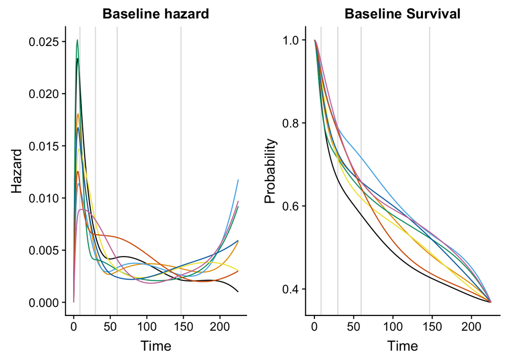

```r
# TODO: Replace with direct calls to surv_mspline_t
p1 <- ggplot(data=mutate(map_dfr(1:nsimplex_samps, ~tibble(y=msp_plot_2[,.], time=times_plot, sample=.)), sample=as.factor(sample)))+
  geom_vline(xintercept = knots, alpha=.5, color='gray')+
  geom_line(mapping = aes(x=time, y=y, color=sample))+
  ggtitle("Baseline hazard")+
  xlab("Time")+
  ylab("Hazard")+
  guides( color=FALSE)+
  scale_fill_manual(values=cbbPalette)+
  scale_colour_manual(values=cbbPalette)


# p2<- ggplot(data=mutate(map_dfr(1:nsimplex_samps, ~tibble(y=isp_plot_2[,.], time=times_plot, sample=.)), sample=as.factor(sample)))+
#   geom_vline(xintercept = knots, alpha=.5, color='gray')+
#   geom_line(mapping = aes(x=time, y=y, color=sample))+
#   ggtitle("Cumulative Baseline hazard")+
#   xlab("Time")+
#   ylab("Cumulative Hazard")+
#   guides( color=FALSE)+
#   scale_fill_manual(values=cbbPalette)+
#   scale_colour_manual(values=cbbPalette)

p3<- ggplot(data=mutate(map_dfr(1:nsimplex_samps, ~tibble(y=exp(-isp_plot_2[,.]), time=times_plot, sample=.)), sample=as.factor(sample)))+
  geom_vline(xintercept = knots, alpha=.5, color='gray')+
  geom_line(mapping = aes(x=time, y=y, color=sample))+
  ggtitle("Baseline Survival")+
  xlab("Time")+
  ylab("Probability")+
  guides( color=FALSE)+
  scale_fill_manual(values=cbbPalette)+
  scale_colour_manual(values=cbbPalette)

cowplot::plot_grid(p1,p3,ncol=2)
```

```r
i_spline_basis_evals <- iSpline(times, knots=knots, degree=mspline_degree,
                                intercept=FALSE, Boundary.knots = c(0, time_max))
m_spline_basis_evals <- deriv(i_spline_basis_evals)
i_spline_basis_evals_censored <- i_spline_basis_evals[msk_censored,]
i_spline_basis_evals_uncensored <- i_spline_basis_evals[!msk_censored,]
m_spline_basis_evals_uncensored <- m_spline_basis_evals[!msk_censored,]
nbasis <- dim(i_spline_basis_evals_censored)[2]




stan_data <- list(N_uncensored=N-N_censored,
                  N_censored=N_censored,
                  X_censored=as.matrix(X[msk_censored,]),
                  X_uncensored=as.matrix(X[!msk_censored,]),
                  times_censored=times[msk_censored],
                  times_uncensored = times[!msk_censored],
                  NC=ncol(X),
                  m=nbasis,
                  m_spline_basis_evals_uncensored=m_spline_basis_evals_uncensored,
                  i_spline_basis_evals_uncensored=i_spline_basis_evals_uncensored,
                  i_spline_basis_evals_censored=i_spline_basis_evals_censored,
                  alpha=dirichlet_alpha
)

fit <- sampling(sm, data=stan_data, seed=42, chains=4, cores=2, iter=4000)
fit2 <- sampling(sm2, data=stan_data, seed=42, chains=4, cores=2, iter=4000)

post <- as.array(fit)
post2 <- as.array(fit2)
```

# Posterior

## Constant

```r
broom::tidy(fit, conf.int=T) %>% filter(! term %in%  c(sprintf("times_uncensored_sampled[%d]", 1:stan_data$N_uncensored),
                                                       sprintf("log_lik[%d]", 1:N)
                                                       ))
```

| term | estimate | std.error | conf.low | conf.high |
| --- | --- | --- | --- | --- |
| betas[1] | 0.9120308 | 0.4929379 | -0.02513026 | 1.927267 |
| intercept | -4.8892776 | 0.2206339 | -5.34302320 | -4.470291 |

## M-spline

```r
broom::tidy(fit2, conf.int=T) %>% filter(! term %in%  sprintf("log_lik[%d]", 1:N))
```

| term | estimate | std.error | conf.low | conf.high |
| --- | --- | --- | --- | --- |
| gammas[1] | 0.06297578 | 0.03663009 | 0.01046016 | 0.1520471 |
| gammas[2] | 0.11270839 | 0.05916027 | 0.02272431 | 0.2479374 |
| gammas[3] | 0.26290778 | 0.09082219 | 0.09657033 | 0.4500756 |
| gammas[4] | 0.15234745 | 0.08703848 | 0.02130650 | 0.3549312 |
| gammas[5] | 0.15576172 | 0.08337220 | 0.02879545 | 0.3435610 |
| gammas[6] | 0.14017452 | 0.08024914 | 0.02140493 | 0.3247635 |
| gammas[7] | 0.11312436 | 0.07348233 | 0.01430522 | 0.2909119 |
| betas[1] | 0.84559668 | 0.49587060 | -0.05097496 | 1.8944696 |
| intercept | 0.36942203 | 0.25002528 | -0.14395606 | 0.8430120 |

## Hazards

### M-Spline

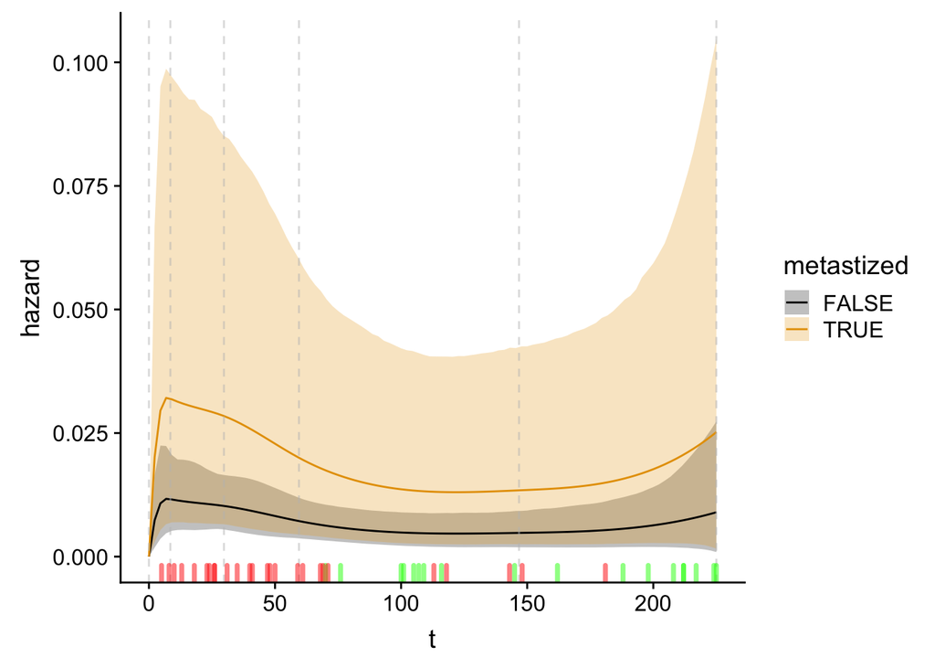

```r
intercepts <- as.vector(post2[,,"intercept"])
betas <- t(matrix(post2[,,sprintf("betas[%d]" ,1:ncol(X))], dim(post2)[1]*dim(post2)[2], ncol(X)))
gammas <- t(matrix(post2[,,sprintf("gammas[%d]", 1:nbasis)], dim(post2)[1]*dim(post2)[2], nbasis))

X_surv = as.matrix(c(0,1))
times_plot <- seq(0, time_max, length.out = 100)
i_spline_basis_evals <- iSpline(times_plot, knots=knots, degree=mspline_degree,
                                intercept=FALSE, Boundary.knots = c(0, time_max))
m_spline_basis_evals <- deriv(i_spline_basis_evals)
hazards <- purrr::map(1:length(times_plot), ~rowMeans(hazard_mspline_t(m_spline_basis_evals[.,], X_surv, gammas, intercepts, betas)))
quantile_func <- function(x, probs) {
  x <- as.data.frame(t(x))
  map_dbl(x, ~quantile(., probs=probs))
}
hazards_low <- purrr::map(1:length(times_plot), ~quantile_func(hazard_mspline_t(m_spline_basis_evals[.,], X_surv, gammas, intercepts, betas),probs=c(0.025)))
hazards_up <- purrr::map(1:length(times_plot), ~quantile_func(hazard_mspline_t(m_spline_basis_evals[.,], X_surv, gammas, intercepts, betas),probs=c(0.975)))
hazards_df <- dplyr::bind_rows(
  tibble(
  t=times_plot,
  metastized=F,
  hazard=map_dbl(hazards, ~.[[1]]),
  hazard_low=map_dbl(hazards_low,~.[[1]]),
  hazard_up=map_dbl(hazards_up,~.[[1]])

  ),
    tibble(
  t=times_plot,
  metastized=T,
  hazard=map_dbl(hazards, ~.[[2]]),
  hazard_low=map_dbl(hazards_low,~.[[2]]),
  hazard_up=map_dbl(hazards_up,~.[[2]])
  ))
  ggplot(data=hazards_df) +
  geom_ribbon(mapping=aes(x=t,ymin=hazard_low, ymax=hazard_up, fill=metastized), alpha=.25)+
  geom_line(mapping=aes(x=t, y=hazard, color=metastized))+
  geom_vline(xintercept = c(0,knots, time_max), alpha=.5, color='gray', linetype='dashed')+
  geom_rug(data=tibble(times=times[is_censored]), aes(x=times), col="green",alpha=0.5, size=1.25)+
  geom_rug(data=tibble(times=times[!is_censored]), aes(x=times), col="red",alpha=0.5, size=1.25)+
  scale_fill_manual(values=cbbPalette)+
  scale_colour_manual(values=cbbPalette)
```

```r
  hazards_df
```

| t | metastized | hazard | hazard_low | hazard_up |
| --- | --- | --- | --- | --- |
| 0.000000 | FALSE | 0.000000000 | 0.0000000000 | 0.000000000 |
| 2.272727 | FALSE | 0.007360827 | 0.0018364065 | 0.016505323 |
| 4.545455 | FALSE | 0.010772279 | 0.0036019682 | 0.022467169 |
| 6.818182 | FALSE | 0.011688466 | 0.0047119817 | 0.022376972 |
| 9.090909 | FALSE | 0.011559222 | 0.0052213237 | 0.020569347 |
| 11.363636 | FALSE | 0.011364640 | 0.0053869364 | 0.019657095 |
| 13.636364 | FALSE | 0.011197173 | 0.0054215685 | 0.019609067 |
| 15.909091 | FALSE | 0.011050649 | 0.0053903970 | 0.019425200 |
| 18.181818 | FALSE | 0.010918898 | 0.0053606648 | 0.019050495 |
| 20.454545 | FALSE | 0.010795749 | 0.0054174813 | 0.018499221 |

[output cut: 190 more lines]

## Survival curves

### M-Spline

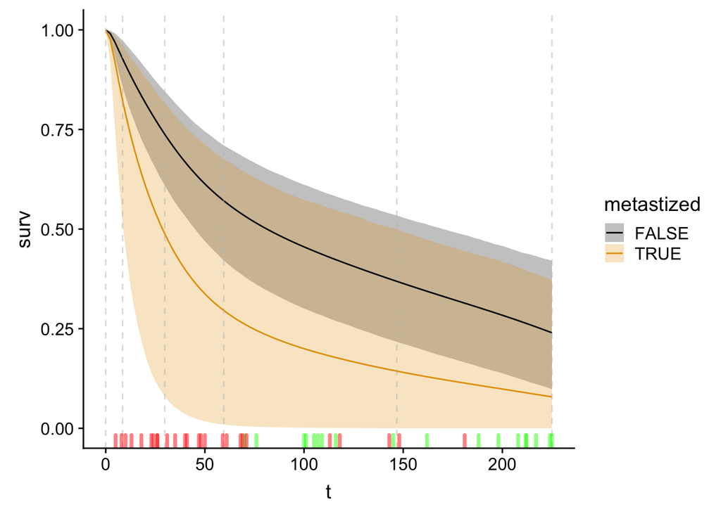

```r
intercepts <- as.vector(post2[,,"intercept"])
betas <- t(matrix(post2[,,sprintf("betas[%d]" ,1:ncol(X))], dim(post2)[1]*dim(post2)[2], ncol(X)))
gammas <- t(matrix(post2[,,sprintf("gammas[%d]", 1:nbasis)], dim(post2)[1]*dim(post2)[2], nbasis))

X_surv = as.matrix(c(0,1))
times_plot <- seq(0, time_max, length.out = 100)
i_spline_basis_evals <- iSpline(times_plot, knots=knots, degree=mspline_degree,
                                intercept=FALSE, Boundary.knots = c(0, time_max))

survs <- purrr::map(1:length(times_plot), ~rowMeans(surv_mspline_t(i_spline_basis_evals[.,], X_surv, gammas, intercepts, betas)))
quantile_func <- function(x, probs) {
  x <- as.data.frame(t(x))
  map_dbl(x, ~quantile(., probs=probs))
}
survs_low <- purrr::map(1:length(times_plot), ~quantile_func(surv_mspline_t(i_spline_basis_evals[.,], X_surv, gammas, intercepts, betas),probs=c(0.025)))
survs_up <- purrr::map(1:length(times_plot), ~quantile_func(surv_mspline_t(i_spline_basis_evals[.,], X_surv, gammas, intercepts, betas),probs=c(0.975)))
surv_df <- dplyr::bind_rows(
  tibble(
  t=times_plot,
  metastized=F,
  surv=map_dbl(survs, ~.[[1]]),
  surv_low=map_dbl(survs_low,~.[[1]]),
  surv_up=map_dbl(survs_up,~.[[1]])

  ),
    tibble(
  t=times_plot,
  metastized=T,
  surv=map_dbl(survs, ~.[[2]]),
  surv_low=map_dbl(survs_low,~.[[2]]),
  surv_up=map_dbl(survs_up,~.[[2]])
  ))
  ggplot(data=surv_df) +
  geom_ribbon(mapping=aes(x=t,ymin=surv_low, ymax=surv_up, fill=metastized), alpha=.25)+
  geom_line(mapping=aes(x=t, y=surv, color=metastized))+
  geom_vline(xintercept = c(0,knots, time_max), alpha=.5, color='gray', linetype='dashed')+
  geom_rug(data=tibble(times=times[is_censored]), aes(x=times), col="green",alpha=0.5, size=1.25)+
  geom_rug(data=tibble(times=times[!is_censored]), aes(x=times), col="red",alpha=0.5, size=1.25)+
  scale_fill_manual(values=cbbPalette)+
  scale_colour_manual(values=cbbPalette)+
  ylim(c(0,1))
```

```r
  surv_df
```

| t | metastized | surv | surv_low | surv_up |
| --- | --- | --- | --- | --- |
| 0.000000 | FALSE | 1.00000000 | 1.000000e+00 | 1.0000000 |
| 2.272727 | FALSE | 0.99080514 | 9.791238e-01 | 0.9979578 |
| 4.545455 | FALSE | 0.97010966 | 9.351147e-01 | 0.9916692 |
| 6.818182 | FALSE | 0.94555797 | 8.884662e-01 | 0.9816998 |
| 9.090909 | FALSE | 0.92109813 | 8.471384e-01 | 0.9697410 |
| 11.363636 | FALSE | 0.89766787 | 8.114707e-01 | 0.9569835 |
| 13.636364 | FALSE | 0.87519606 | 7.808649e-01 | 0.9432905 |
| 15.909091 | FALSE | 0.85360086 | 7.507525e-01 | 0.9302243 |
| 18.181818 | FALSE | 0.83281585 | 7.232048e-01 | 0.9156378 |
| 20.454545 | FALSE | 0.81278564 | 6.987163e-01 | 0.9015117 |

[output cut: 190 more lines]

### Constant

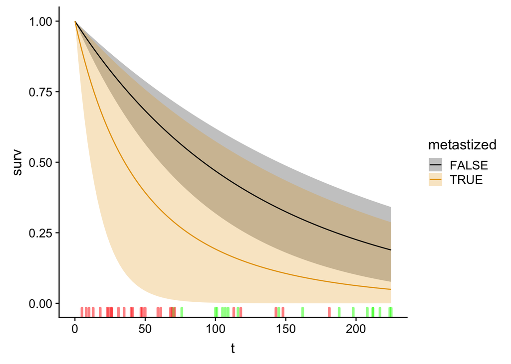

```r
intercepts <- as.vector(post[,,"intercept"])
betas <- t(matrix(post[,,sprintf("betas[%d]" ,1:ncol(X))], dim(post)[1]*dim(post)[2], ncol(X)))
X_surv = as.matrix(c(0,1))
times_plot <- seq(0, time_max, length.out = 100)
survs <- purrr::map(times_plot, ~rowMeans(surv_const_t(., X_surv, intercepts, betas)))
survs_low <- purrr::map(times_plot, ~quantile_func(surv_const_t(., X_surv, intercepts, betas),probs=c(0.025)))
survs_up <- purrr::map(times_plot, ~quantile_func(surv_const_t(., X_surv, intercepts, betas),probs=c(0.975)))
surv_df <- dplyr::bind_rows(
  tibble(
  t=times_plot,
  metastized=F,
  surv=map_dbl(survs, ~.[[1]]),
  surv_low=map_dbl(survs_low,~.[[1]]),
  surv_up=map_dbl(survs_up,~.[[1]])

  ),
    tibble(
  t=times_plot,
  metastized=T,
  surv=map_dbl(survs, ~.[[2]]),
  surv_low=map_dbl(survs_low,~.[[2]]),
  surv_up=map_dbl(survs_up,~.[[2]])
  ))
  ggplot(data=surv_df) +
  geom_ribbon(mapping=aes(x=t,ymin=surv_low, ymax=surv_up, fill=metastized), alpha=.25)+
  geom_line(mapping=aes(x=t, y=surv, color=metastized))+
  geom_rug(data=tibble(times=times[is_censored]), aes(x=times), col="green",alpha=0.5, size=1.25)+
  geom_rug(data=tibble(times=times[!is_censored]), aes(x=times), col="red",alpha=0.5, size=1.25)+
  scale_fill_manual(values=cbbPalette)+
  scale_colour_manual(values=cbbPalette)+
  ylim(c(0,1))
```

```r
  surv_df
```

| t | metastized | surv | surv_low | surv_up |
| --- | --- | --- | --- | --- |
| 0.000000 | FALSE | 1.00000000 | 1.000000e+00 | 1.0000000 |
| 2.272727 | FALSE | 0.98263707 | 9.743263e-01 | 0.9891920 |
| 4.545455 | FALSE | 0.96558983 | 9.493117e-01 | 0.9785009 |
| 6.818182 | FALSE | 0.94885228 | 9.249393e-01 | 0.9679253 |
| 9.090909 | FALSE | 0.93241855 | 9.011926e-01 | 0.9574639 |
| 11.363636 | FALSE | 0.91628286 | 8.780557e-01 | 0.9471157 |
| 13.636364 | FALSE | 0.90043956 | 8.555127e-01 | 0.9368793 |
| 15.909091 | FALSE | 0.88488312 | 8.335485e-01 | 0.9267535 |
| 18.181818 | FALSE | 0.86960811 | 8.121482e-01 | 0.9167372 |
| 20.454545 | FALSE | 0.85460920 | 7.912973e-01 | 0.9068291 |

[output cut: 190 more lines]

# Brier Score (LOO-PSIS)

## Introduction

Denote by $\mathbf{T}_{-i}$ the $N-1$ dimensional vector of observed times (censored and uncensored) for all individuals, except for individual $i$. Write $S_i(t\vert \mathbf{T}_{-i})$ for the expected survival probability of patient $i$ at time $t$, where the expectation is with respect to the posterior over all latent model parameters $\theta$, given observations $\mathbf{T}_{-i}$.

Now, suppose $\{\theta_s\}_{s=1\dots S}$ is a (correlated) sequence of latent model parameters drawn from the posterior, given *all* observed times (including the one from individual $i$). We then can approximate $S_i(t\vert \mathbf{T}_{-i})$ as follows

$$S_i(t\vert \mathbf{T}_{-i}) \approx \frac{\sum_{s=1}^S r_{s,i} S_i(t\vert \theta_s)}{\sum_{s=1}^S r_{s,i}}$$

where $S_i(t\vert \theta_s)$ is the probability that individual $i$ survives beyond time $t$, given latent parameters $\theta_s$ and

$$r_{s,i} \equiv \frac{1}{p(T_i\vert \theta_s)}$$
Now, define

$$\eta_{i,t} \equiv \left\{ 1_{\{T_i > t\}} - S_i(t\vert \mathbf{T}_{-i})\right\}^2$$

Based on the residuals $\eta_{i}(t)$ we define, following Gerds et al, the inverse probability of censoring weighted estimator $\Omega(t)$, defined as

$$\Omega(t)\equiv \frac{1}{N} \sum_{i=1}^N w_i(t)\eta_{i}(t)^2$$

with

$$w_i(t) \equiv \frac{\mathbf{1}_{\{T_i \leq t\}} \delta_i}{G_i(T_i)} + \frac{\mathbf{1}_{\{T_i > t\}}}{G_i(t)}$$

Here $\delta_i$ is the event indicator, i.e. $\delta_i = 1$ iff individual experienced the event and $0$ otherwise. Moreover $G_i(t)$ is the probability that the censoring time $C_i$ is exceeds $t$ for patient $i$. Note that for both the event and censoring survival functions we indicate a potential dependence on covariates by adding the index $i$. $G_i(t)$ can be obtained by fitting, for example, a Cox model to the data with reversed censoring indicators. By introducing a weighting based on $G_i$ we guarantee that the estimator’s bias $\Omega(t)$ does not depent on the survival model (otherwise model comparison would be hard), see Gerds et al. It can be shown, see Gerds et al., that under weaks conditions, $\Omega(t)$ is a uniformly consistent estimator for the expected mean squared error in time (aka Brier score).

We provide function `surv_loo` (which is survival model agnostic) that can be used to calculate $S_i(t\vert \mathbf{T}_{-i})$ for all $i$ and required times $t$, based on estimates of $S_i(t\vert \theta_s)$. This matrix $\{S_i(t\vert \mathbf{T}_{-i})\}_{i,t}$ can then be passed to the function `pec()` part of the `pec` R Package, which calculates $\Omega(t)$ and provides ways to choose $G_i$, see the code below.

## Comparison

```r
intercepts <- as.vector(post[,,"intercept"])
betas <- t(matrix(post[,,sprintf("betas[%d]" ,1:ncol(X))], dim(post)[1]*dim(post)[2], ncol(X)))
X_surv = as.matrix(c(0,1))
times_pec <- seq(0, time_max, length.out = 100)
survs1 <- purrr::map(times_pec, ~rowMeans(surv_const_t(., X, intercepts, betas)))
survs1 <- do.call(cbind, survs1)

log_ratios <- -post[,,sprintf("log_lik[%d]",1:N)]
r_eff <- relative_eff(exp(log_ratios))
psis_result <- psis(log_ratios, r_eff = r_eff)
w <- matrix(weights(psis_result, log=FALSE), nrow=dim(X)[1], byrow = T) # TODO: check if this is correct reshaping!
survs_loo_psis1 <- do.call(cbind, purrr::map(times_pec,~surv_loo(surv_const_t(., X, intercepts, betas), w)))
```

```r
# This calculates the true Loo
do_loo <- function(idx) {
  df_ <- slice(df, -idx)
  N_ <- nrow(df_)
  X_ <- as.matrix(as.integer(pull(df_, metastized))-1)
  is_censored_ <- pull(df_,event)==0
  times_ <- pull(df_,time)
  msk_censored_ <- is_censored_ == 1
  N_censored_ <- sum(msk_censored_)

  stan_data_ <- list(N_uncensored=N_-N_censored_,
                    N_censored=N_censored_,
                    X_censored=as.matrix(X_[msk_censored_,]),
                    X_uncensored=as.matrix(X_[!msk_censored_,]),
                    times_censored=times_[msk_censored_],
                    times_uncensored = times_[!msk_censored_],
                    NC=ncol(X_)
  )
  fit_ <- sampling(sm, data=stan_data_, seed=42, chains=4, cores=2, iter=4000)
  post_ <- as.array(fit_)
  intercepts_ <- as.vector(post_[,,"intercept"])
  betas_ <- t(matrix(post_[,,sprintf("betas[%d]" ,1:ncol(X_))], dim(post_)[1]*dim(post_)[2], ncol(X_)))
  purrr::map_dbl(times_pec, ~as.vector(rowMeans(surv_const_t(., as.matrix(X[idx]), intercepts_, betas_))))

}
survs_loo1 <- do.call(rbind, purrr::map(1:nrow(df), do_loo))
```

```r
intercepts <- as.vector(post2[,,"intercept"])
betas <- t(matrix(post2[,,sprintf("betas[%d]" ,1:ncol(X))], dim(post2)[1]*dim(post2)[2], ncol(X)))
gammas <- t(matrix(post2[,,sprintf("gammas[%d]", 1:nbasis)], dim(post2)[1]*dim(post2)[2], nbasis))
times_pec <- seq(0, time_max, length.out = 100)
i_spline_basis_evals <- iSpline(times_pec, knots=knots, degree=mspline_degree,
                                intercept=FALSE, Boundary.knots = c(0, time_max))

survs2 <- purrr::map(1:length(times_pec), ~rowMeans(surv_mspline_t(i_spline_basis_evals[.,], X, gammas,intercepts, betas)))
survs2 <- do.call(cbind, survs2)

log_ratios2 <- -post2[,,sprintf("log_lik[%d]",1:N)]
r_eff2 <- relative_eff(exp(log_ratios2))
psis_result2 <- psis(log_ratios2, r_eff = r_eff2)
w2<- matrix(weights(psis_result2, log=FALSE), nrow=dim(X)[1], byrow = T) # TODO: check if this is correct reshaping!


survs_loo_psis2 <- do.call(cbind, purrr::map(1:length(times_pec),~surv_loo(surv_mspline_t(i_spline_basis_evals[.,], X, gammas, intercepts, betas), w2)))
```

```r
# This calculates the true Loo
do_loo <- function(idx) {
  df_ <- slice(df, -idx)
  N_ <- nrow(df_)
  X_ <- as.matrix(as.integer(pull(df_, metastized))-1)
  is_censored_ <- pull(df_,event)==0
  times_ <- pull(df_,time)
  msk_censored_ <- is_censored_ == 1
  N_censored_ <- sum(msk_censored_)
  i_spline_basis_evals <- iSpline(times_, knots=knots, degree=mspline_degree,
                                  intercept=FALSE, Boundary.knots = c(0, time_max))
  m_spline_basis_evals <- deriv(i_spline_basis_evals)
  i_spline_basis_evals_censored <- i_spline_basis_evals[msk_censored_,]
  i_spline_basis_evals_uncensored <- i_spline_basis_evals[!msk_censored_,]
  m_spline_basis_evals_uncensored <- m_spline_basis_evals[!msk_censored_,]
  nbasis <- dim(i_spline_basis_evals_censored)[2]
  stan_data_ <- list(N_uncensored=N_-N_censored_,
                    N_censored=N_censored_,
                    X_censored=as.matrix(X_[msk_censored_,]),
                    X_uncensored=as.matrix(X_[!msk_censored_,]),
                    times_censored=times_[msk_censored_],
                    times_uncensored = times_[!msk_censored_],
                    NC=ncol(X_),
                    m=nbasis,
                    m_spline_basis_evals_uncensored=m_spline_basis_evals_uncensored,
                    i_spline_basis_evals_uncensored=i_spline_basis_evals_uncensored,
                    i_spline_basis_evals_censored=i_spline_basis_evals_censored,
                    alpha=dirichlet_alpha
  )
  fit_ <- sampling(sm2, data=stan_data_, seed=42, chains=4, cores=2, iter=4000)
  post_ <- as.array(fit_)
  intercepts_ <- as.vector(post_[,,"intercept"])
  betas_ <- t(matrix(post_[,,sprintf("betas[%d]" ,1:ncol(X_))], dim(post_)[1]*dim(post_)[2], ncol(X_)))
  gammas_ <- t(matrix(post_[,,sprintf("gammas[%d]", 1:nbasis)], dim(post_)[1]*dim(post_)[2], nbasis))
  i_spline_basis_evals_ <- iSpline(times_pec, knots=knots, degree=mspline_degree,
                                intercept=FALSE, Boundary.knots = c(0, time_max))
  purrr::map_dbl(1:length(times_pec), ~as.vector(rowMeans(surv_mspline_t(i_spline_basis_evals_[.,], as.matrix(X[idx]), gammas_,intercepts_, betas_))))
}
survs_loo2 <- do.call(rbind, purrr::map(1:nrow(df), do_loo))
```

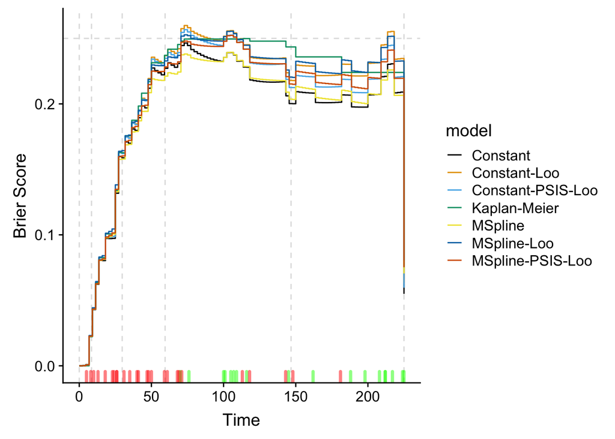

```r
pec_rslt <- pec(list("MSpline-PSIS-Loo"=survs_loo_psis2,
                     "MSpline-Loo"=survs_loo2,
                     "Constant-Loo"=survs_loo1,
                     "Constant-PSIS-Loo"=survs_loo_psis1,
                     "MSpline"=survs2,
                     "Constant"=survs1
                     ), formula =Surv(time,event)~metastized , data=df, exact = F, times = times_pec,cens.model="marginal",
                splitMethod="none",
                B=0,
                verbose=TRUE)

df_pec <- tibble(time=pec_rslt$time, bs=pec_rslt$AppErr[["Constant-Loo"]], model="Constant-Loo") %>%
  bind_rows(tibble(time=pec_rslt$time, bs=pec_rslt$AppErr[["Constant-PSIS-Loo"]], model="Constant-PSIS-Loo")) %>%
  bind_rows(tibble(time=pec_rslt$time, bs=pec_rslt$AppErr[["MSpline-PSIS-Loo"]], model="MSpline-PSIS-Loo")) %>%
    bind_rows(tibble(time=pec_rslt$time, bs=pec_rslt$AppErr[["MSpline-Loo"]], model="MSpline-Loo")) %>%
  bind_rows(tibble(time=pec_rslt$time, bs=pec_rslt$AppErr[["Constant"]], model="Constant")) %>%
  bind_rows(tibble(time=pec_rslt$time, bs=pec_rslt$AppErr[["MSpline"]], model="MSpline")) %>%

  bind_rows(tibble(time=pec_rslt$time, bs=pec_rslt$AppErr[["Reference"]], model="Kaplan-Meier"))
ggplot(data=df_pec) +
  geom_hline(yintercept=.25,alpha=.5, color='gray', linetype='dashed')+
  geom_vline(xintercept = c(0,knots, time_max), alpha=.5, color='gray', linetype='dashed')+
  geom_step(aes(x=time, y=bs, color=model))+
  geom_rug(data=tibble(times=times[is_censored]), aes(x=times), col="green",alpha=0.5, size=1.25)+
  geom_rug(data=tibble(times=times[!is_censored]), aes(x=times), col="red",alpha=0.5, size=1.25)+
  ylab("Brier Score")+
  xlab("Time")+
  scale_fill_manual(values=cbbPalette)+
  scale_colour_manual(values=cbbPalette)
```

```r
trsf_bs <- function(m) {
  dplyr::filter(df_pec, model==m) %>%
    dplyr::select(time, bs) %>%
    dplyr::rename(!!paste("bs",m,sep="_") := bs)
}

purrr::map(unique(df_pec$model),trsf_bs) %>%
  purrr::reduce(left_join, by = "time")
```

| time | bs_Constant-Loo | bs_Constant-PSIS-Loo | bs_MSpline-PSIS-Loo | bs_MSpline-Loo | bs_Constant | bs_MSpline | bs_Kaplan-Meier |
| --- | --- | --- | --- | --- | --- | --- | --- |
| 0.000000 | 0.0000000000 | 6.816812e-30 | 9.613402e-30 | 0.000000e+00 | 0.0000000000 | 0.0000000000 | 0.00000000 |
| 2.272727 | 0.0002390777 | 2.378911e-04 | 6.845882e-05 | 6.719884e-05 | 0.0002346469 | 0.0000665616 | 0.00000000 |
| 4.545455 | 0.0009393608 | 9.346398e-04 | 7.235221e-04 | 7.102633e-04 | 0.0009221677 | 0.0007039397 | 0.00000000 |
| 6.818182 | 0.0225634428 | 2.255505e-02 | 2.261411e-02 | 2.307436e-02 | 0.0224410961 | 0.0225900306 | 0.02221074 |
| 9.090909 | 0.0431540964 | 4.314093e-02 | 4.326027e-02 | 4.430101e-02 | 0.0428722510 | 0.0431953327 | 0.04338843 |
| 11.363636 | 0.0627488712 | 6.270522e-02 | 6.263656e-02 | 6.432463e-02 | 0.0622344207 | 0.0624993302 | 0.06353306 |
| 13.636364 | 0.0813170641 | 8.125901e-02 | 8.074364e-02 | 8.305625e-02 | 0.0805463007 | 0.0805309293 | 0.08264463 |
| 15.909091 | 0.0812391820 | 8.116419e-02 | 8.162568e-02 | 8.407908e-02 | 0.0803317942 | 0.0812479164 | 0.08264463 |
| 18.181818 | 0.0985267824 | 9.842695e-02 | 9.825290e-02 | 1.012411e-01 | 0.0972930691 | 0.0977712764 | 0.10072314 |
| 20.454545 | 0.0985200772 | 9.839890e-02 | 9.955187e-02 | 1.025967e-01 | 0.0971283161 | 0.0988622808 | 0.10072314 |

[output cut: 90 more lines]

### Constant only

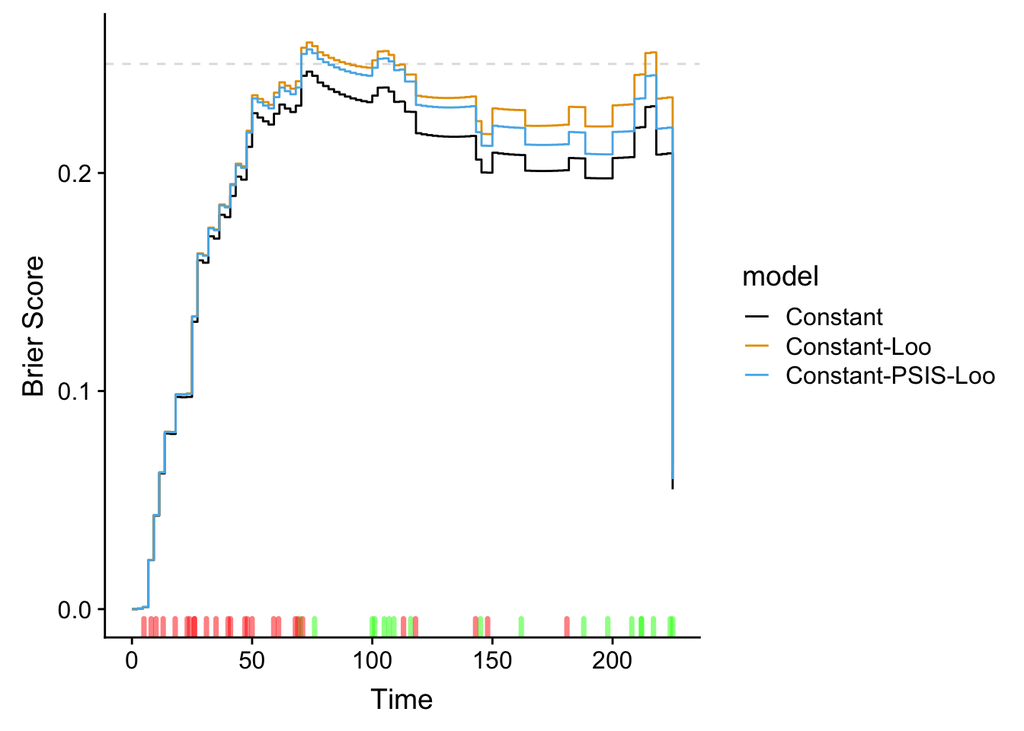

```r
pec_rslt <- pec(list("Constant-Loo"=survs_loo1,
                     "Constant"=survs1,
                     "Constant-PSIS-Loo"=survs_loo_psis1
                     ), formula =Surv(time,event)~metastized , data=df, exact = F, times = times_pec,cens.model="marginal",
                splitMethod="none",
                B=0,
                verbose=TRUE)

df_pec <- tibble(time=pec_rslt$time, bs=pec_rslt$AppErr[["Constant-Loo"]], model="Constant-Loo") %>%
  bind_rows(tibble(time=pec_rslt$time, bs=pec_rslt$AppErr[["Constant"]], model="Constant")) %>%
    bind_rows(tibble(time=pec_rslt$time, bs=pec_rslt$AppErr[["Constant-PSIS-Loo"]], model="Constant-PSIS-Loo"))


ggplot(data=df_pec) +
  geom_hline(yintercept=.25,alpha=.5, color='gray', linetype='dashed')+
  geom_step(aes(x=time, y=bs, color=model))+
  geom_rug(data=tibble(times=times[is_censored]), aes(x=times), col="green",alpha=0.5, size=1.25)+
  geom_rug(data=tibble(times=times[!is_censored]), aes(x=times), col="red",alpha=0.5, size=1.25)+
  ylab("Brier Score")+
  xlab("Time")+
  scale_fill_manual(values=cbbPalette)+
  scale_colour_manual(values=cbbPalette)
```

```r
purrr::map(unique(df_pec$model),trsf_bs) %>%
  purrr::reduce(left_join, by = "time")
```

| time | bs_Constant-Loo | bs_Constant | bs_Constant-PSIS-Loo |
| --- | --- | --- | --- |
| 0.000000 | 0.0000000000 | 0.0000000000 | 6.816812e-30 |
| 2.272727 | 0.0002390777 | 0.0002346469 | 2.378911e-04 |
| 4.545455 | 0.0009393608 | 0.0009221677 | 9.346398e-04 |
| 6.818182 | 0.0225634428 | 0.0224410961 | 2.255505e-02 |
| 9.090909 | 0.0431540964 | 0.0428722510 | 4.314093e-02 |
| 11.363636 | 0.0627488712 | 0.0622344207 | 6.270522e-02 |
| 13.636364 | 0.0813170641 | 0.0805463007 | 8.125901e-02 |
| 15.909091 | 0.0812391820 | 0.0803317942 | 8.116419e-02 |
| 18.181818 | 0.0985267824 | 0.0972930691 | 9.842695e-02 |
| 20.454545 | 0.0985200772 | 0.0971283161 | 9.839890e-02 |

[output cut: 90 more lines]

### MSpline only

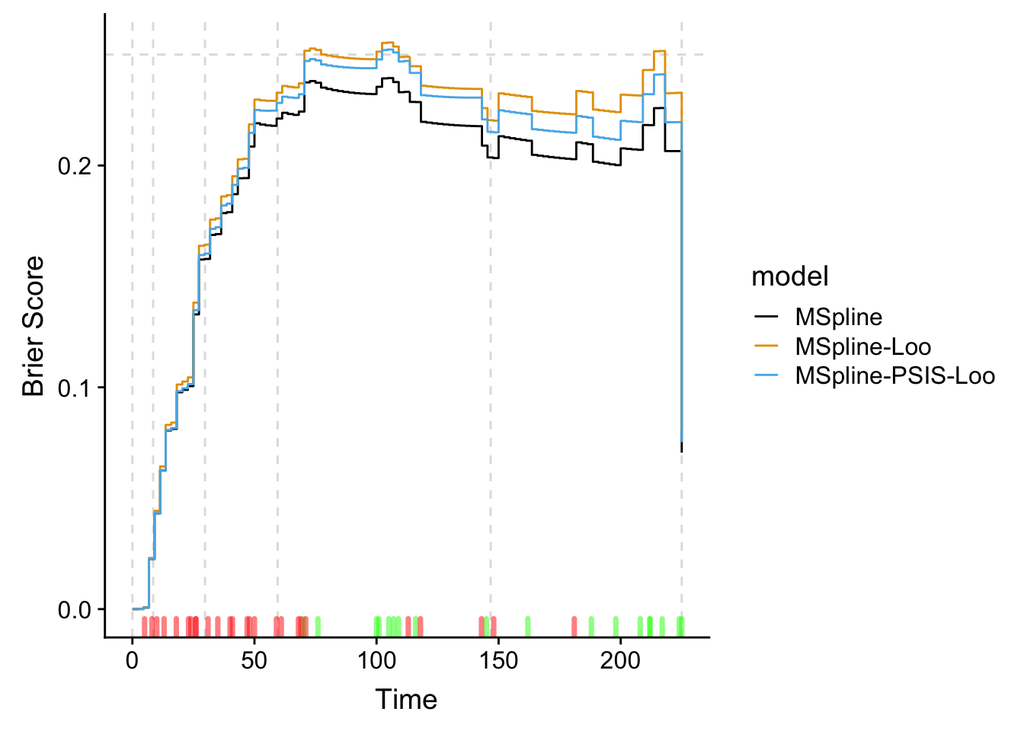

```r
pec_rslt <- pec(list("MSpline-Loo"=survs_loo2,
                     "MSpline"=survs2,
                     "MSpline-PSIS-Loo"= survs_loo_psis2
                     ), formula =Surv(time,event)~metastized , data=df, exact = F, times = times_pec,cens.model="marginal",
                splitMethod="none",
                B=0,
                verbose=TRUE)

df_pec <- tibble(time=pec_rslt$time, bs=pec_rslt$AppErr[["MSpline-Loo"]], model="MSpline-Loo") %>%
  bind_rows(tibble(time=pec_rslt$time, bs=pec_rslt$AppErr[["MSpline-PSIS-Loo"]], model="MSpline-PSIS-Loo")) %>%
    bind_rows(tibble(time=pec_rslt$time, bs=pec_rslt$AppErr[["MSpline"]], model="MSpline"))


ggplot(data=df_pec) +
  geom_hline(yintercept=.25,alpha=.5, color='gray', linetype='dashed')+
  geom_vline(xintercept = c(0,knots, time_max), alpha=.5, color='gray', linetype='dashed')+
  geom_step(aes(x=time, y=bs, color=model))+
  geom_rug(data=tibble(times=times[is_censored]), aes(x=times), col="green",alpha=0.5, size=1.25)+
  geom_rug(data=tibble(times=times[!is_censored]), aes(x=times), col="red",alpha=0.5, size=1.25)+
  ylab("Brier Score")+
  xlab("Time")+
  scale_fill_manual(values=cbbPalette)+
  scale_colour_manual(values=cbbPalette)
```

```r
purrr::map(unique(df_pec$model),trsf_bs) %>%
  purrr::reduce(left_join, by = "time")
```

| time | bs_MSpline-Loo | bs_MSpline-PSIS-Loo | bs_MSpline |
| --- | --- | --- | --- |
| 0.000000 | 0.000000e+00 | 9.613402e-30 | 0.0000000000 |
| 2.272727 | 6.719884e-05 | 6.845882e-05 | 0.0000665616 |
| 4.545455 | 7.102633e-04 | 7.235221e-04 | 0.0007039397 |
| 6.818182 | 2.307436e-02 | 2.261411e-02 | 0.0225900306 |
| 9.090909 | 4.430101e-02 | 4.326027e-02 | 0.0431953327 |
| 11.363636 | 6.432463e-02 | 6.263656e-02 | 0.0624993302 |
| 13.636364 | 8.305625e-02 | 8.074364e-02 | 0.0805309293 |
| 15.909091 | 8.407908e-02 | 8.162568e-02 | 0.0812479164 |
| 18.181818 | 1.012411e-01 | 9.825290e-02 | 0.0977712764 |
| 20.454545 | 1.025967e-01 | 9.955187e-02 | 0.0988622808 |

[output cut: 90 more lines]